# Visualization in R

February 06 2017

## Outline of Lecture

- Background of ggplot2
- The grammar of graphics
  - Layers
  - Mappings
- Scatterplot Example
  - Geoms
  - Customizing the plot
- Other geom examples

## Background of ggplot2

- Data visualiation package and plotting system for R
- Created by Hadley Wickham, Chief Scientist at RStudio
- Takes the "good parts" of lattice and base
  - Can provide plots for many conditions (facet_wrap())
  - Can provide many plots on one screen
- None of the "bad parts"
  - Can add to geoms/annotation plots in "layers", intuitive and simple
  - Overall more intuitive, but sometimes need to look up syntax
- Based on concepts from The Grammar of Graphics by Leland Wilkinson (2005)
- The ggplot2 package has become one of the most widely used in the R language

## Comparing ggplot2 to base graphics / lattice

- Compared to base graphics:
  - ggplot2 is more verbose for simple, canned graphics
  - ggplot2 is less verbose for more complicated, original graphics
- Compared to lattice:
  - ggplot2 provides a more consistent approach across functionalities
  - Lattice has no "grammar of graphics"
  - Both packages can provide "trellis" graphs
    - Display variables or relationships between variables conditioned on another variable (faceting)

## The Grammar of Graphics

- The Grammar of Graphics was published by Leland Wilkinson in 2005
- What do we mean, grammar?
  - "The fundamental principles or rules of an art or science"
  - Essentially, separate visualizations into components, and build visualizations piece-by-piece
- We'll follow Hadley's adaptation of the Grammar of Graphics, employed in ggplot2
  - Data maps to aesthetics which are represented by geoms, creating layers
  - Graphics are composed of one or more layers

## Layers

- Each layer is composed of essentially 4 parts
  - Data and aesthetic mapping
  - A statistical transformation of the data (identity)
  - a geometric object to represent in the graphic
  - a position adjustment (if necessary, i.e. random jitters, dodges)

## Making the Abstract Concrete

- Below is a data frame that we will use to create a scatterplot

| group | age | weight |
| --- | --- | --- |
| A | 11.94790 | 89.94737 |
| A | 14.07684 | 111.61247 |
| A | 15.90149 | 128.54394 |
| B | 17.12472 | 141.89406 |
| B | 18.71858 | 157.91150 |

## Data Defined: now what?

- We may be interested in constructing a scatterplot of weight vs age
- Must define our aesthetics for the plot

| group | x | y |
| --- | --- | --- |
| A | 11.94790 | 89.94737 |
| A | 14.07684 | 111.61247 |
| A | 15.90149 | 128.54394 |
| B | 17.12472 | 141.89406 |
| B | 18.71858 | 157.91150 |

## Our First ggplot2 Scatterplot

- Scatterplot code below

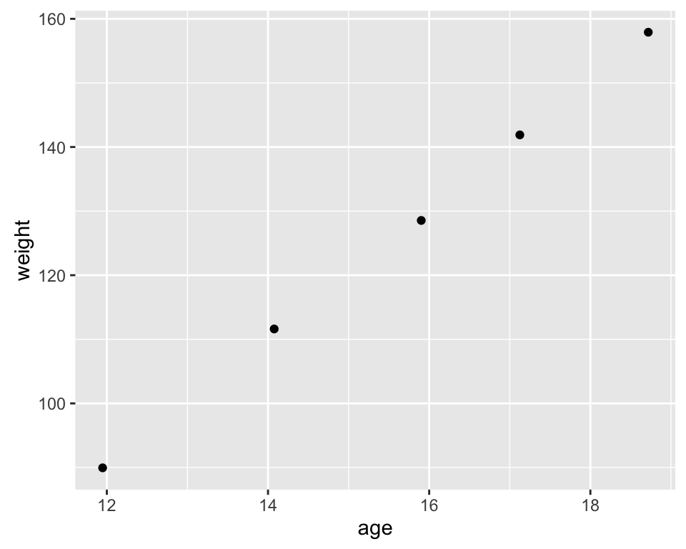

```r
ggplot() + geom_point(data = df1, mapping = aes(x = age,
  y = weight), stat = "identity")
```

## Explaining Our First ggplot2 Scatterplot

- The call to ggplot() tells R that we want to use ggplot2 functionality
  - You can specify the dataset here to use the same data for all layers in your plot
  - ggplot(data = df1) + …
- The call to geom_point() separated by a "+" creates the aesthetic mappings and determines the geom to use
- Argument stat = "identity" tells ggplot to not transform or aggregate the data
  - The stat argument is a little confusing. It doesn't mean, "log", "square root", etc.
  - Think of this as more of a summary of the data, i.e. "boxplot", "identity", etc.

## Explaining Our First ggplot2 Scatterplot

- The data: df
- The aesthetic mappings: age \(\rightarrow\) x, weight \(\rightarrow\) y
- The geometric object representing the data: point
- The statistical transformation: identity
- Can add more aesthetic mappings, such as color or facet by group
- Can add more geoms, such as lines, smoothers, etc.

## Our First ggplot2 Scatterplot

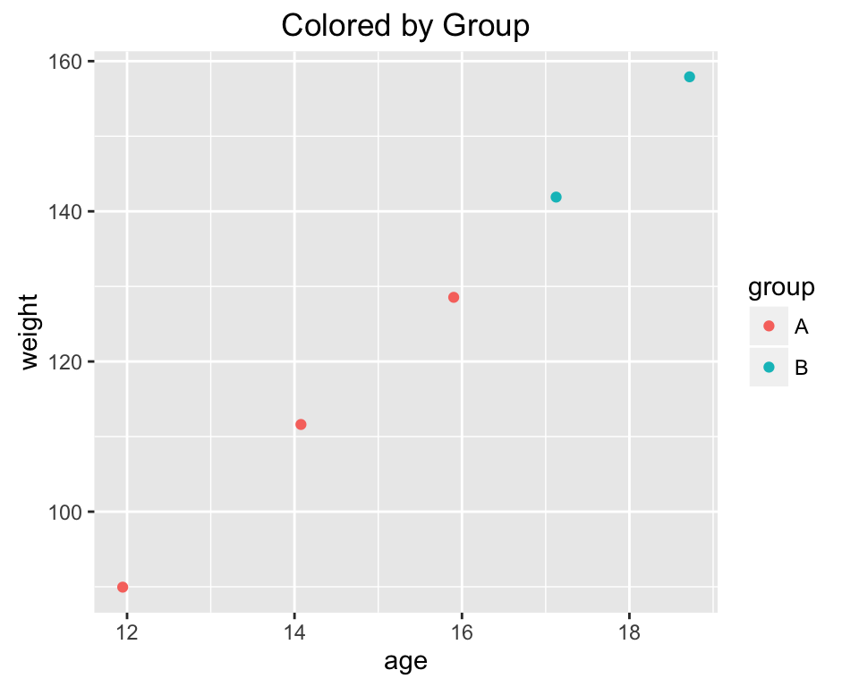

```r
ggplot() +
  geom_point(data = df1, mapping = aes(x = age, y = weight,
  colour = group), stat = "identity")
```

## Our First ggplot2 Scatterplot

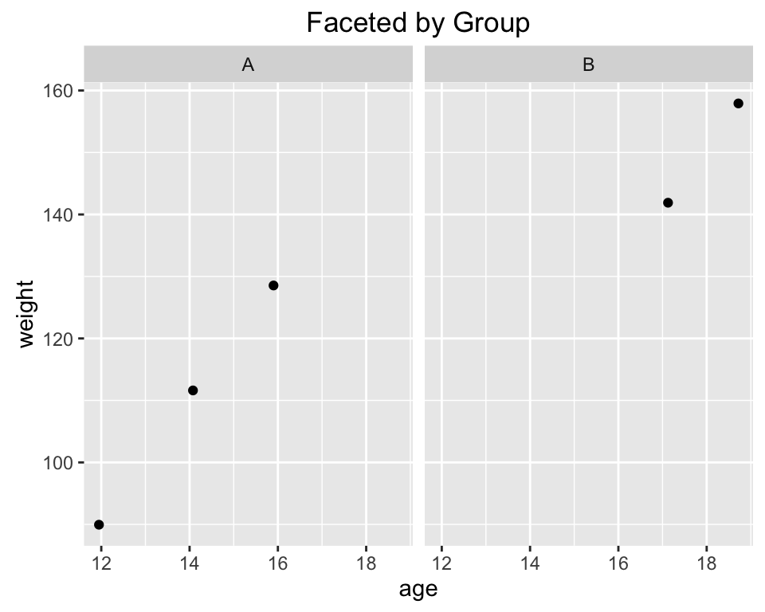

```r
ggplot() +
  geom_point(data = df1, mapping = aes(x = age, y = weight),
  stat = "identity") + facet_wrap( ~ group)
```

## Geometric objects

- Geomertric objects determine how our aesthetic mappings manifest in a visualization
  - Points
  - Bars
  - Lines
  - Paths
  - …
- The ggplot2 package uses geom_xxx() as a general format for selecting geoms to represent a chosen aesthetic mapping.

## Scales

- Scales control or govern the mapping from data to an aesthetic property
  - continuous, discrete, etc.
- Each aesthetic mapping requires a scale
  - ggplot2 uses defaults scales whenever possible
  - these were employed in our scatterplot example
- Discrete scales are more often necessary to explicitly code for legends
  - scale_colour_discrete(), scale_colour_manual()
  - scale_shape_discrete(), scale_shape_manual()
- Continuous scales can be explicitly coded:
  - scale_x_continuous(), scale_y_continuous

## Our First ggplot2 Scatterplot revisited

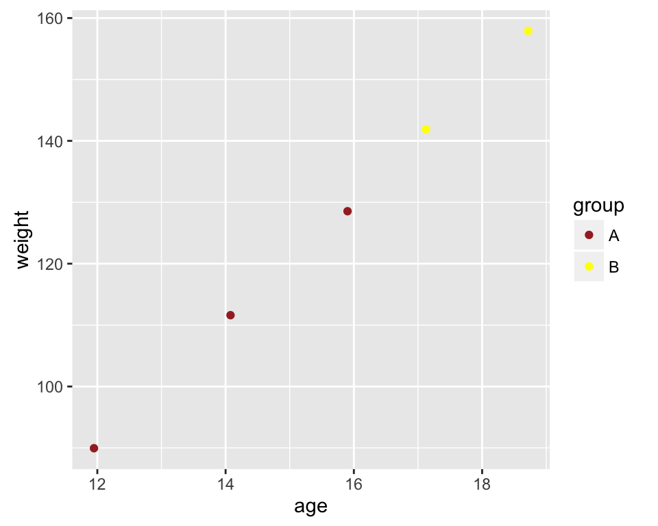

```r
ggplot() +
  geom_point(data = df1, mapping = aes(x = age, y = weight,
  colour = group), stat = "identity")) + scale_colour_manual(
  values = c("brown", "yellow"))
```

## A More Complete Scatterplot

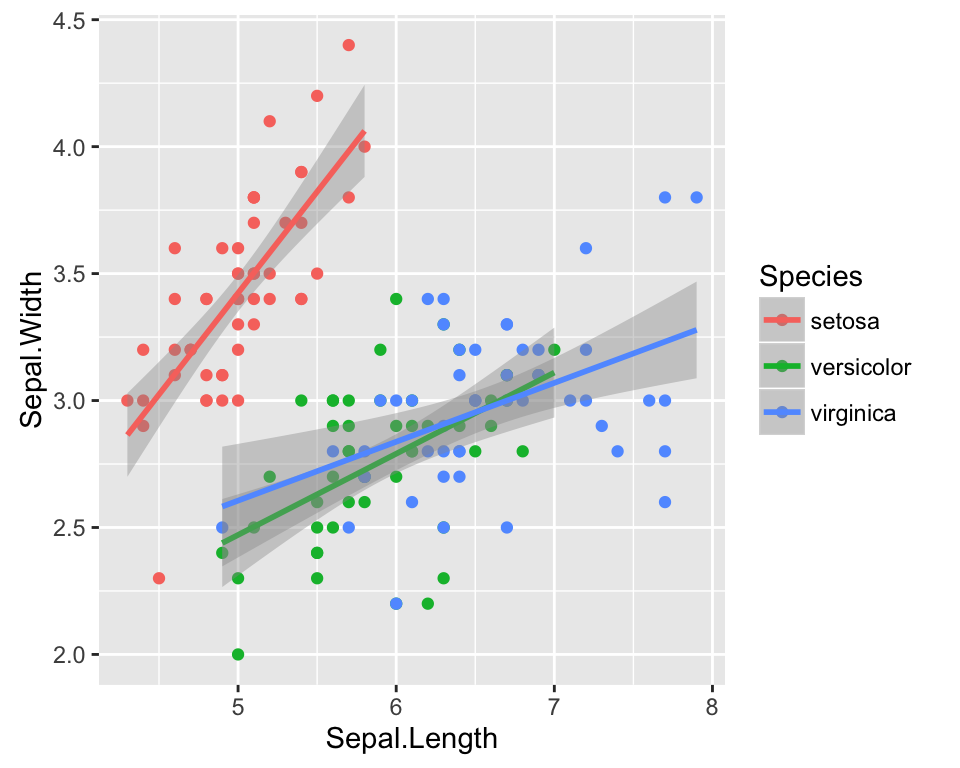

```r
ggplot(data = iris, aes(x = Sepal.Length, y = Sepal.Width,
  colour = Species)) + geom_point() + geom_smooth(method = "lm")
```

## A More Complete Scatterplot

- A lot more customization possible
  - Remove the confidence bands by setting argument se to FALSE in geom_smooth
  - Change x and y axis names with xlab() and ylab()
  - Add title with ggtitle()
  - Backgrounds can be changed, the grid can be removed, etc.
  - Non-linear smoothers can be used

## A More Complete Scatterplot

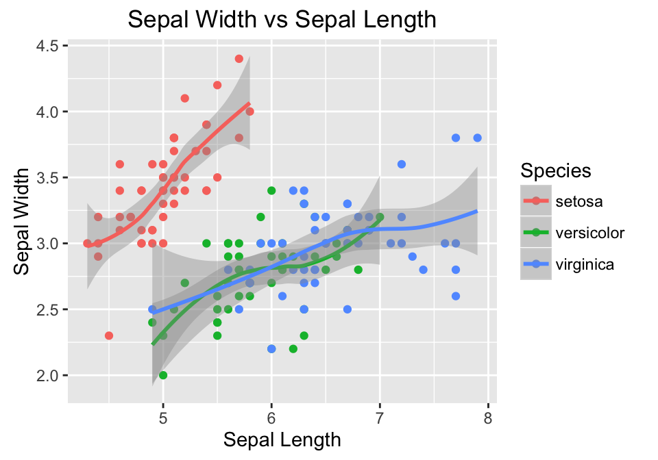

```r
ggplot(data = iris, aes(x = Sepal.Length, y = Sepal.Width,
  colour = Species)) + geom_point() + geom_smooth(
  method = "loess", span = 0.9) + ylab("Sepal Width") +
  xlab("Sepal Length") + ggtitle("Sepal Width vs Sepal Length")
```

## A Spaghetti Plot in ggplot2

- Using a transformed version of the tb dataset from EDAWR package

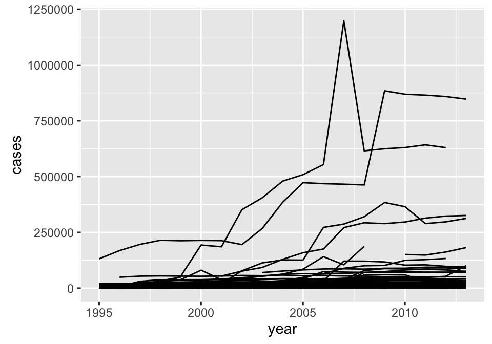

```r
ggplot() + geom_line(data = tb2, aes(x = year,
  y = cases, group = country))
```

## Improving our Spaghetti Plot

- Perhaps faceted by country?

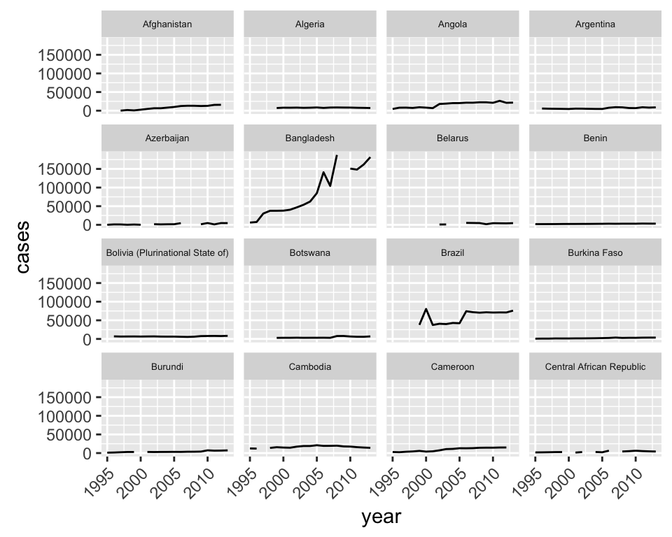

```r
ggplot() + geom_line(data = tb2, aes(x = year,
  y = cases, group = country)) + facet_wrap( ~ country)
```

## A Simple Histogram

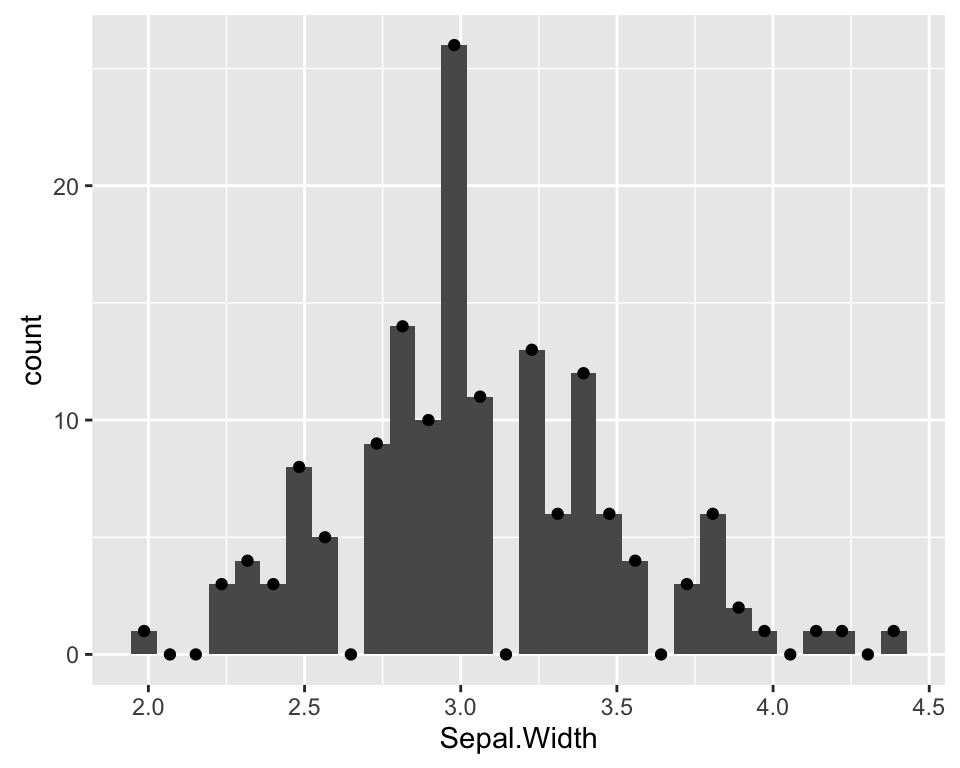

```r
ggplot(data = iris, aes(x = Sepal.Width)) + geom_histogram() +
  geom_point(stat = "bin")
```

## A Better Looking Histogram

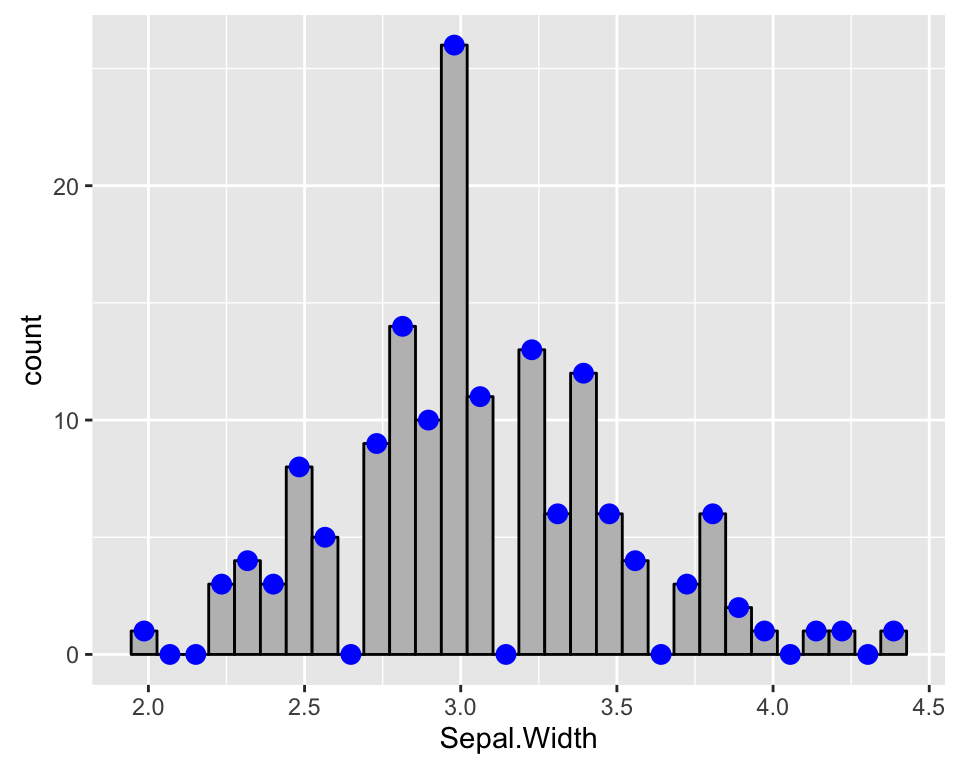

```r
ggplot(data = iris, aes(x = Sepal.Width)) + geom_histogram(
  stat = "bin", fill = "grey", colour = "black") +
  geom_point(stat = "bin", size = 3, colour = "blue")
```

## A Better Looking Histogram - Decomposed

- The above plot is composed of two layers
  - A layer using the histogram geom (or rectangle)
  - A layer using the point geom
- Here's the breakdown of each layer
  - data: iris
  - aesthetic: x = Sepal.Width
  - geometric object: histogram/point
  - transformation: "bin" - based on binwidth, bin the values
  - positional adjustment - none

## The Intelligence of ggplot2

- The concept of layering
- We can "abuse" the intelligence to shorten our code
  - Most geom_xxx() function's have default behavior
  - Don't need to specify stat = "bin" for geom_histogram()
  - Similarly, don't need to specify stat = "boxplot" for geom_boxplot()
  - Don't need stat = "identity" for geom_point(), geom_line()
- If using the same data for each layer, specify data in ggplot() call
- Same for aesthetic mappings

## Recreating a Famous Graphic - Napoleon's March

- Data from Napoleon's historic attempt to defeat Russia
- Often referred to simply as "The French Invasion of Russia"
  - June to December 1812
  - Russia retreated from Smolensk, where Napoleon had a great victory
  - Burned and pillaged their own villages while retreating, preventing Napoleon's army from living off the land
  - Slowly wittled away at his army as they continued to chase the Russian army into the interior of Russia

## Recreating a Famous Graphic - Napoleon's March

- Will recreate Charles Joseph Minard's famous graphic of the march
  - Shows the ever decreasing size of Napoleon's army on their way to Moscow and retreating back to France
  - Minard was a civil engineer who contributed much to information graphics/statistical graphics
  - Small sample of data below

| long | lat | survivors | direction | group |
| --- | --- | --- | --- | --- |
| 24.0 | 54.9 | 340000 | A | 1 |
| 24.5 | 55.0 | 340000 | A | 1 |
| 25.5 | 54.5 | 340000 | A | 1 |
| 26.0 | 54.7 | 320000 | A | 1 |
| 27.0 | 54.8 | 300000 | A | 1 |
| 28.0 | 54.9 | 280000 | A | 1 |
| 28.5 | 55.0 | 240000 | A | 1 |
| 29.0 | 55.1 | 210000 | A | 1 |
| 30.0 | 55.2 | 180000 | A | 1 |
| 30.3 | 55.3 | 175000 | A | 1 |
| 32.0 | 54.8 | 145000 | A | 1 |
| 33.2 | 54.9 | 140000 | A | 1 |
| 34.4 | 55.5 | 127100 | A | 1 |
| 35.5 | 55.4 | 100000 | A | 1 |
| 36.0 | 55.5 | 100000 | A | 1 |
| 37.6 | 55.8 | 100000 | A | 1 |
| 37.7 | 55.7 | 100000 | R | 1 |
| 37.5 | 55.7 | 98000 | R | 1 |
| 37.0 | 55.0 | 97000 | R | 1 |
| 36.8 | 55.0 | 96000 | R | 1 |
| 35.4 | 55.3 | 87000 | R | 1 |
| 34.3 | 55.2 | 55000 | R | 1 |
| 33.3 | 54.8 | 37000 | R | 1 |
| 32.0 | 54.6 | 24000 | R | 1 |
| 30.4 | 54.4 | 20000 | R | 1 |
| 29.2 | 54.3 | 20000 | R | 1 |
| 28.5 | 54.2 | 20000 | R | 1 |
| 28.3 | 54.3 | 20000 | R | 1 |
| 27.5 | 54.5 | 20000 | R | 1 |
| 26.8 | 54.3 | 12000 | R | 1 |
| 26.4 | 54.4 | 14000 | R | 1 |
| 25.0 | 54.4 | 8000 | R | 1 |
| 24.4 | 54.4 | 4000 | R | 1 |
| 24.2 | 54.4 | 4000 | R | 1 |
| 24.1 | 54.4 | 4000 | R | 1 |
| 24.0 | 55.1 | 60000 | A | 2 |
| 24.5 | 55.2 | 60000 | A | 2 |
| 25.5 | 54.7 | 60000 | A | 2 |
| 26.6 | 55.7 | 40000 | A | 2 |
| 27.4 | 55.6 | 33000 | A | 2 |
| 28.7 | 55.5 | 33000 | A | 2 |
| 28.7 | 55.5 | 33000 | R | 2 |
| 29.2 | 54.2 | 30000 | R | 2 |
| 28.5 | 54.1 | 30000 | R | 2 |
| 28.3 | 54.2 | 28000 | R | 2 |
| 24.0 | 55.2 | 22000 | A | 3 |
| 24.5 | 55.3 | 22000 | A | 3 |
| 24.6 | 55.8 | 6000 | A | 3 |
| 24.6 | 55.8 | 6000 | R | 3 |
| 24.2 | 54.4 | 6000 | R | 3 |
| 24.1 | 54.4 | 6000 | R | 3 |

## The ggplot2 Code

```r
ggplot(data = troops, aes(x = long, y = lat)) + geom_path(
  aes(size = survivors, colour = direction, group = group),
  lineend = "round") + geom_text(aes(label = city, y = lat + 0.06),
  size = 3, data = cities) + geom_point(aes(x = long, y = lat),
  data = cities) + scale_size(range = c(1,10)) + theme_light() +
  scale_x_continuous(limits=c(24,39)) + ylab("Latitude") +
  xlab("Longitude") + scale_colour_manual(values = c("grey50",
  "red")) + ggtitle("Napoleon's March on Moscow")
```

## The Resulting Plot

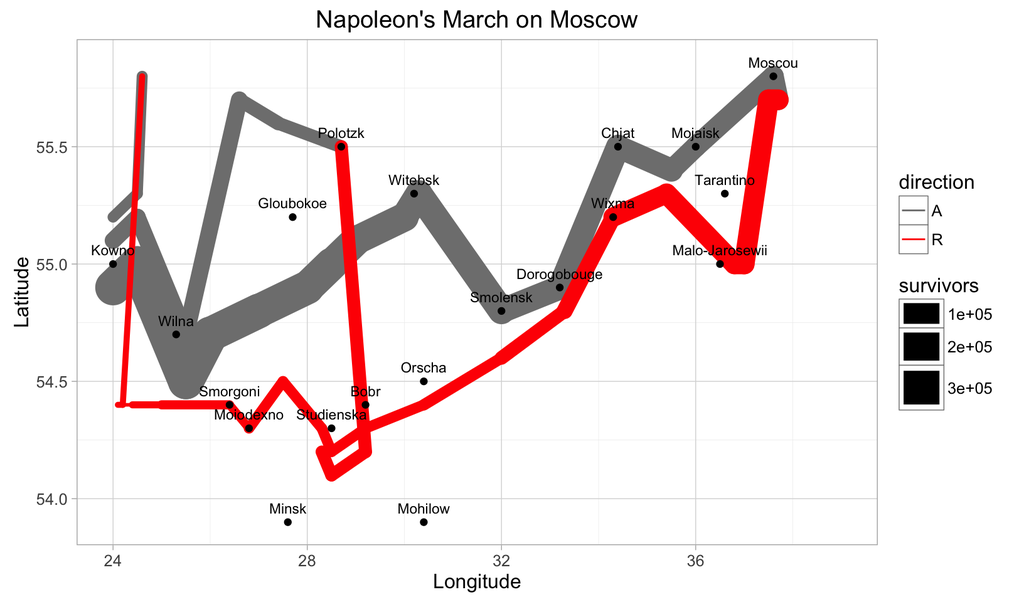